# Regression Analysis for Open Pipeline & Revenue

Hilary Lai

2020-08-13

```r
library(readr)
library(tidyverse)
library(knitr)
library(lubridate)
options(digits=2)
options(scipen = 1)

#get the open peak annual value file downloaded from QV
open.pav <- read_csv("open_pav.csv", col_types = cols(Snapshot_Month = col_date(format = "%m/%d/%Y")))[,-7] %>%
  mutate(Fiscal_Mth = year(Snapshot_Month) * 100 + month(Snapshot_Month))
rev <- read_csv("rev_by_mth.csv")
#align director and region
rev <- rev %>%
  mutate(Director = case_when(
      rev$Director == "Hong, SK" ~ "SHONG",
      rev$Director == "Hsu, Eric" ~ "EHSU2",
      rev$Director == "JD Kang" ~ "JKANG2",
      rev$Director == "Ted Park" ~ "TPARK",
      rev$Director == "Wan, Daryl" ~ "MWAN"),
      Region = case_when(
        Region == "Asean" ~ "AS",
        Region == "Australia" ~ "AL",
        Region == "India" ~ "IN",
        Region == "Korea" ~ "KR",
        Region == "Taiwan" ~ "TA"))

#fix revenue format
rev$Revenue <- gsub("[(]", "-", rev$Revenue)
rev$Revenue <- gsub("[),$]", "", rev$Revenue)

#summarise revenue by variables
rev <-  rev %>%
  group_by(End_Mkt_Segment, Fiscal_Mth, Director, Region, BU) %>%
  dplyr::summarise(Revenue = sum(as.numeric(Revenue)))

#align column names
names(open.pav)[c(3,5)] <- c("End_Mkt_Segment", "BU")
dat <- full_join(rev, open.pav[,-6]) %>%
  filter(Fiscal_Mth >= 201811 & Fiscal_Mth <= 202007)
dat[is.na(dat)] <- 0
dat <- dat %>%
  filter(log(Revenue)>0, log(PAV)>0)
```

# Dataset

The dataset contains the following fields:

- Fiscal month
- Director
- PAV
- Revenue

A partial look of part of the dataset:

```r
library(knitr)
#get the final table
options(knitr.kable.NA = '')
kable(head(dat))
```

| End_Mkt_Segment | Fiscal_Mth | Director | Region | BU | Revenue | PAV |
| --- | --- | --- | --- | --- | --- | --- |
| AEG | 201811 | EHSU2 | TA | ADEFTG | 144815 | 2980700 |
| AEG | 201811 | EHSU2 | TA | AEGTG | 178021 | 1588304 |
| AEG | 201811 | EHSU2 | TA | AEITG | 42278 | 3827447 |
| AEG | 201811 | EHSU2 | TA | CHNTG | 371 | 86528 |
| AEG | 201811 | EHSU2 | TA | COMTG | 42146 | 675178 |
| AEG | 201811 | EHSU2 | TA | CSTG | 34458 | 1511320 |

# ANOVA (Analysis of Variance) with all Variables

*Note:*

*1. To keep all values positive for transformation, I only included data with PAV & Revenue > 0. The purpose of keeping all values positive is to keep the distribution of variables normal, so that it meets model requirements for regression analysis.*

*2. The 0.1 comes from Box-Cox Transformation of data. The purpose is to make data normal in order to meet the requirements for linear regression analysis. We will use this value from now on.*

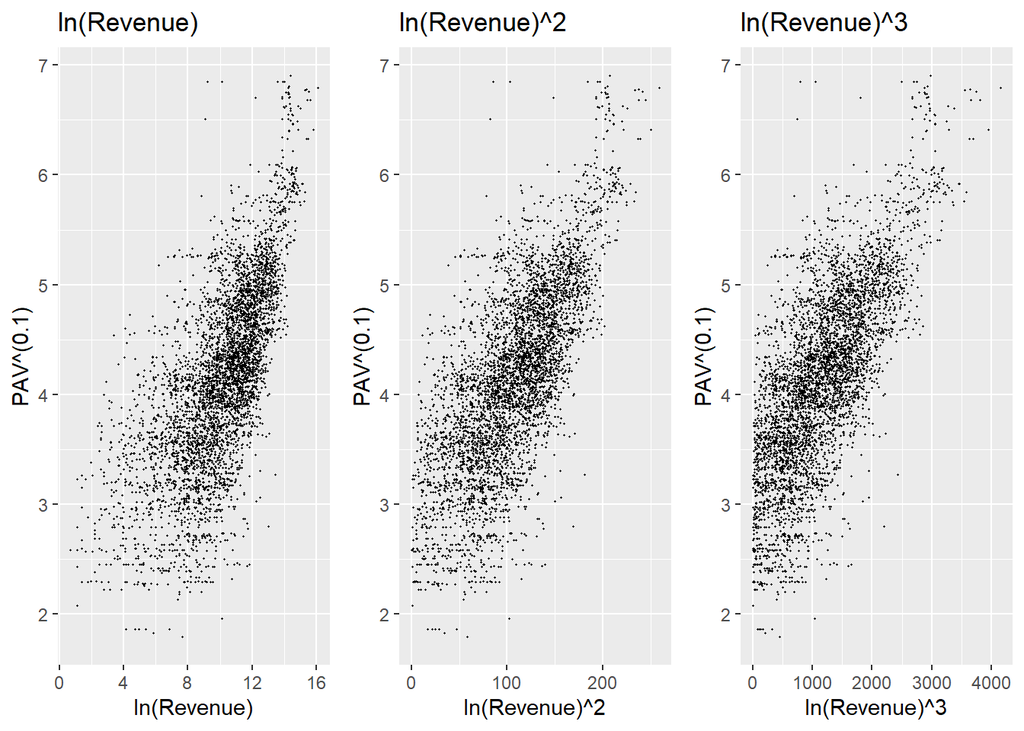

```r
plot_grid(plot.1, plot.2, plot.3, ncol = 3)
```

## Results:

```r
#show the summary results
summary.aov(dat.fit)
```

```
##                       Df Sum Sq Mean Sq F value Pr(>F)
## I((log(Revenue))^2)    1   1705    1705  6184.4 <2e-16 ***
## End_Mkt_Segment        6    146      24    88.5 <2e-16 ***
## Director               4     53      13    48.1 <2e-16 ***
## BU                     9     93      10    37.6 <2e-16 ***
## Residuals           4734   1305       0
## ---
## Signif. codes:  0 '***' 0.001 '**' 0.01 '*' 0.05 '.' 0.1 ' ' 1
```

# Linear Regression Model A: 4 independent and 1 dependent variables

Next, I run linear regression analysis for each variable, including director, BU, and end market segment. The reason I did not use Region is that it is correlated to Director, which would violate linear regression requirements.

The linear model should look something like this:

### $(PAV)^{(0.1)}$ = $\beta_0$ + $\beta_1$ * $\ln(Revenue)^2$ + … + $\epsilon$

*Note: $\epsilon$ = Error variable, $\beta_0$ = intercept.*

## Results (A):

```r
summary(dat.fit)
```

```
##
## Call:
## lm(formula = PAV^lamb ~ I((log(Revenue))^2) + End_Mkt_Segment +
##     Director + BU, data = dat)
##
## Residuals:
##     Min      1Q  Median      3Q     Max
## -2.1220 -0.3244  0.0061  0.3104  3.0530
##
## Coefficients:
##                      Estimate Std. Error t value Pr(>|t|)
## (Intercept)          3.365103   0.039470   85.26  < 2e-16 ***
## I((log(Revenue))^2)  0.010773   0.000207   52.00  < 2e-16 ***
## End_Mkt_SegmentASD  -0.186009   0.030880   -6.02  1.8e-09 ***
## End_Mkt_SegmentAUT   0.053323   0.029810    1.79  0.07372 .
## End_Mkt_SegmentCOM  -0.149330   0.028803   -5.18  2.3e-07 ***
## End_Mkt_SegmentCON  -0.221650   0.029135   -7.61  3.3e-14 ***
## End_Mkt_SegmentDHC  -0.529754   0.030647  -17.29  < 2e-16 ***
## End_Mkt_SegmentINS  -0.273139   0.027261  -10.02  < 2e-16 ***
## DirectorJKANG2       0.223293   0.043948    5.08  3.9e-07 ***
## DirectorMWAN        -0.245482   0.020686  -11.87  < 2e-16 ***
## DirectorSHONG       -0.055403   0.024300   -2.28  0.02265 *
## DirectorTPARK       -0.054038   0.038287   -1.41  0.15819
## BUAEGTG             -0.159089   0.038982   -4.08  4.6e-05 ***
## BUAEITG             -0.056911   0.029849   -1.91  0.05663 .
## BUCHNTG             -0.549558   0.048777  -11.27  < 2e-16 ***
## BUCOMTG              0.049774   0.029417    1.69  0.09071 .
## BUCSTG              -0.213615   0.032178   -6.64  3.5e-11 ***
## BUDHCTG             -0.035023   0.047137   -0.74  0.45752
## BUOTH               -0.905467   0.526144   -1.72  0.08533 .
## BUPPGTG              0.173434   0.029419    5.90  4.0e-09 ***
## BUPTPTG             -0.109628   0.029970   -3.66  0.00026 ***
## ---
## Signif. codes:  0 '***' 0.001 '**' 0.01 '*' 0.05 '.' 0.1 ' ' 1
##
## Residual standard error: 0.52 on 4734 degrees of freedom
## Multiple R-squared:  0.605,  Adjusted R-squared:  0.603
## F-statistic:  362 on 20 and 4734 DF,  p-value: <2e-16
```

The model has an adjusted $R^2$ value of 0.60, which means that it is quite useful (60% of data can be represented by the equation). Hence, we can use it for forecasting current PAV given a revenue value.

We can get the equation:

$\text(PAV)^{(0.1)}$ = (3.37) + (0.01) * $\ln(Revenue)^2$ + (-0.19) * (ASD) + (0.05) * (AUT) + (-0.15) * (COM) + (-0.22) * (CON) +(-0.53) * (DHC) + (-0.27) * (INS) +(0.22) * (JKANG2) + (-0.25) * (MWAN) +(-0.06) * (SHONG) +(-0.05) * (TPARK) + (-0.16) * (AEGTG) + (-0.06) * (AEITG) + (-0.55) * (CHNTG) + (0.05) * (COMTG) + (-0.21) * (CSTG) + (-0.04) * (DHCTG) + (-0.91) * (OTH) + (0.17) * (PPGTG) + (-0.11) * (PTPTG)

*Note: For both director and segment categories, they are presented as dummy variables (either 0 or 1). For example: if Director = Daryl, then MWAN = 1, JKANG2 = SHONG = TPARK = 0.*

## Regression Plots (A)

### By Director

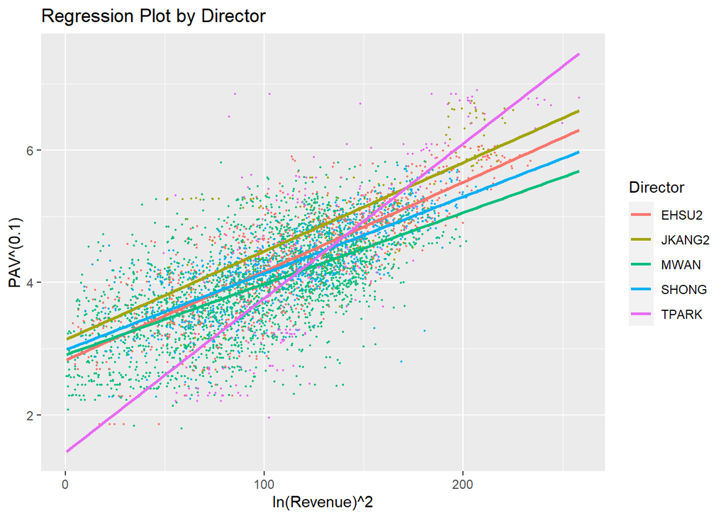

```r
#plot by director
plot.dir <- dat %>%
  ggplot(aes(x = log(Revenue)^2 , y = PAV^lamb, color = Director)) +
  geom_point(size = 0.3) +
   xlab("ln(Revenue)^2")+
  ylab("PAV^(0.1)")+
  ggtitle("Regression Plot by Director") +
  stat_smooth(method = "lm", aes(fill = Director), se=FALSE, fullrange=TRUE)
plot.dir
```

### By Segment

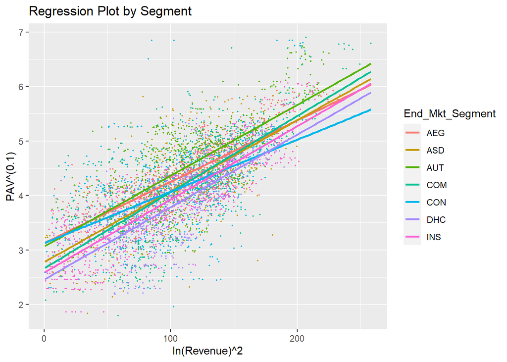

```r
#plot by segment
plot.seg <- dat %>%
  ggplot(aes(x = log(Revenue)^2 , y = PAV^lamb, color = End_Mkt_Segment)) +
  geom_point(size = 0.3) +
   xlab("ln(Revenue)^2")+
  ylab("PAV^(0.1)")+
    ggtitle("Regression Plot by Segment") +
  stat_smooth(method = "lm", aes(fill = End_Mkt_Segment), se=FALSE, fullrange=TRUE)
plot.seg
```

### By Region

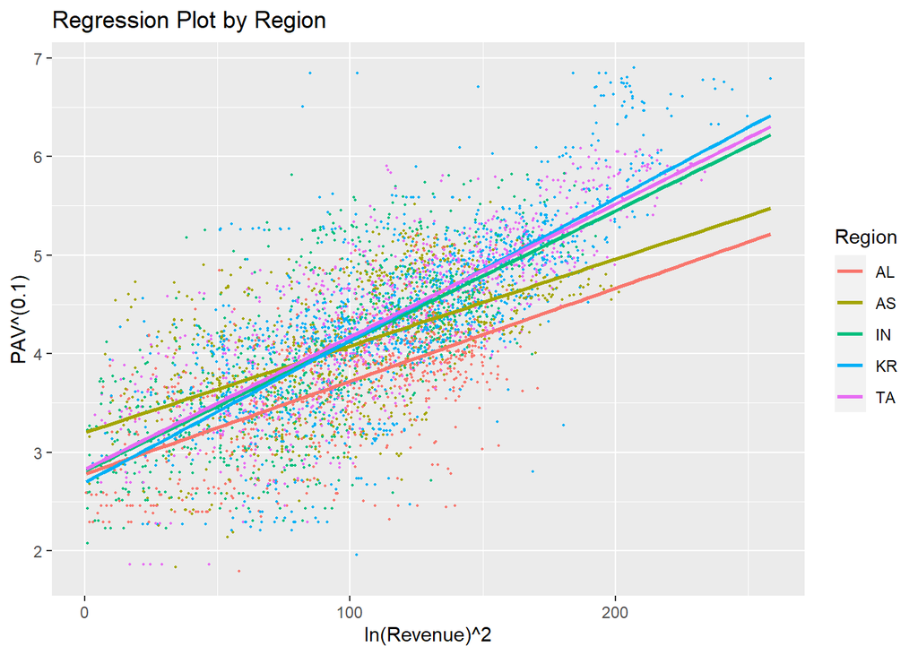

```r
#plot by region
plot.reg <- dat %>%
  ggplot(aes(x = log(Revenue)^2, y = PAV^lamb, color = Region)) +
  geom_point(size = 0.3) +
   xlab("ln(Revenue)^2")+
  ylab("PAV^(0.1)")+
    ggtitle("Regression Plot by Region") +
  stat_smooth(method = "lm", aes(fill = Region), se=FALSE, fullrange=TRUE)
plot.reg
```

# Linear Regression Model B: 1 independent and 1 dependent variables

To simplify the model, let’s only use $\ln(Revenue)^2$ and $(PAV)^{0.1}$ as prediction.

## Results (B):

```r
goal.tbl <- read_csv("goal_seg_reg.csv") #read again
goal <- goal.tbl[[3]]
options(scipen=1)

goal.fit <- lm(PAV^lamb ~ I((log(Revenue))^2), dat)
summary(goal.fit)
```

```
##
## Call:
## lm(formula = PAV^lamb ~ I((log(Revenue))^2), data = dat)
##
## Residuals:
##     Min      1Q  Median      3Q     Max
## -2.1666 -0.3697  0.0053  0.3599  2.9604
##
## Coefficients:
##                     Estimate Std. Error t value Pr(>|t|)
## (Intercept)         2.781902   0.020894   133.2   <2e-16 ***
## I((log(Revenue))^2) 0.012965   0.000182    71.2   <2e-16 ***
## ---
## Signif. codes:  0 '***' 0.001 '**' 0.01 '*' 0.05 '.' 0.1 ' ' 1
##
## Residual standard error: 0.58 on 4753 degrees of freedom
## Multiple R-squared:  0.516,  Adjusted R-squared:  0.516
## F-statistic: 5.07e+03 on 1 and 4753 DF,  p-value: <2e-16
```

As shown, there is strong evidence to show that there exists a linear relationship between $\ln(Revenue)^2$ and $PAV^{0.1}$. Also, about 52% of data can be explained by the model.

We get the equation: $(PAV)^{(0.1)}$ = 2.78 + 0.01 * $\ln(Revenue)^2$.

## Regression Plot (B)

And the plot is shown below:

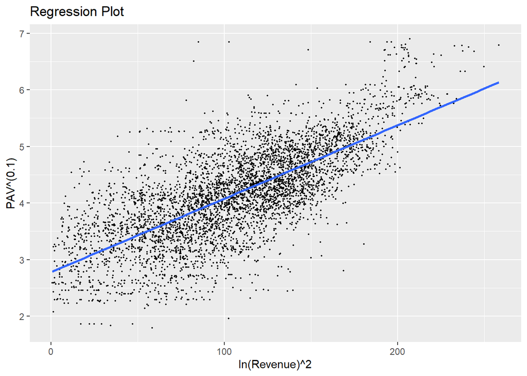

```r
plot.goal <- dat %>%
  ggplot(aes(x = log(Revenue)^2 , y = PAV^lamb)) +
  geom_point(size = 0.3) +
   xlab("ln(Revenue)^2")+
  ylab("PAV^(0.1)")+
  ggtitle("Regression Plot") +
  stat_smooth(method = "lm", se=FALSE, fullrange=TRUE)
plot.goal
```

# Forecast and Predictions

## 2. Example B: Get Predicted PAV to achieve Revenue Goals.

#### **For 2021, there is a revenue goal for each segment and region.**

To calculate the PAV we need in order to achieve the goals, we use the equation from **Model B**:

$(PAV)^{(0.1)}$ = 2.78 + 0.01 * $\ln(Revenue)^2$.

Next, we put in all the revenue goal numbers in the equation, and we can get the table below:

```r
options(knitr.kable.NA = "")
pred.tbl <- pred.tbl %>%
  add_row(`Region (DAR)`= "Total", FY21E = sum(as.numeric(pred.tbl$FY21E)), Expected_PAV = as.numeric(sum(pred.tbl$Expected_PAV)))
pred.tbl$FY21E <-  pred.tbl$FY21E %>%
  format(big.mark=",")
pred.tbl$Expected_PAV <-  pred.tbl$Expected_PAV %>%
  format(big.mark=",")

kable(pred.tbl)
```

| Region (DAR) | Segment | FY21E | Expected_PAV |
| --- | --- | --- | --- |
| AEG | AL | 1,159,003 | 17,810,639 |
|  | AS | 2,318,084 | 28,583,798 |
|  | IN | 10,051,328 | 77,690,144 |
|  | KR | 12,047,000 | 87,859,055 |
|  | TA | 41,685,588 | 203,212,056 |
| ASD | AL | 3,975,351 | 41,304,604 |
|  | AS | 1,531,602 | 21,540,945 |
|  | IN | 11,315,675 | 84,201,720 |
|  | KR | 4,744,000 | 46,597,188 |
|  | TA | 15,000,000 | 101,945,235 |
| AUT | AL | 771,751 | 13,500,610 |
|  | AS | 2,919,645 | 33,459,695 |
|  | IN | 1,512,997 | 21,362,037 |
|  | KR | 82,243,000 | 320,227,117 |
|  | TA | 1,987,122 | 25,730,380 |
| COM | AL | 2,664,602 | 31,435,728 |
|  | AS | 4,775,525 | 46,808,109 |
|  | IN | 7,271,348 | 62,334,642 |
|  | KR | 67,944,000 | 281,899,898 |
|  | TA | 19,876,555 | 123,348,676 |
| CON | AL | 4,241,768 | 43,173,379 |
|  | AS | 3,767,557 | 39,819,064 |
|  | IN | 497,734 | 10,020,569 |
|  | KR | 32,722,000 | 172,677,844 |
|  | TA | 20,389,000 | 125,490,245 |
| DHC | AL | 3,492,903 | 37,814,613 |
|  | AS | 140,997 | 4,283,674 |
|  | IN | 2,827,465 | 32,734,930 |
|  | KR | 16,097,000 | 106,939,282 |
|  | TA | 6,741,945 | 59,207,580 |
| INS | AL | 3,974,625 | 41,299,458 |
|  | AS | 22,338,594 | 133,479,886 |
|  | IN | 5,133,854 | 49,175,026 |
|  | KR | 25,440,000 | 145,727,566 |
|  | TA | 32,389,792 | 171,495,432 |
| Total |  | 475,989,410 | 2,844,190,825 |